# Enrichment Analysis of RNA-Seq of Neuroblastoma Cells

Gepoliano Chaves

August 13th, 2025

In this code notebook my goal is to show how the enrichment plot of signaling pathways enriched in ADRN and MES cells were generated. Here I bring the lists of ADRN and MES genes from a different analysis. I input the two lists of genes to the enricher function of the package clusterProfiler. After the object is created I can look at all the signaling pathways enriched in the ADRN and MES gene lists. I save both ADRN and MES signalings to the same xlsx object using an xlsx package.

### 1. Load libraries

```r
library(clusterProfiler)
library(ggplot2)
```

### 2. Construct msigdb database

```r
##_______________________________________________________##
# 2.2) Normoxia ADRN vs. MES Enrichment

library(msigdbr)
h_gene_sets_H = msigdbr(species = "Homo sapiens", category = c("H"))
h_gene_sets_C2 = msigdbr(species = "Homo sapiens", category = c("C2"))
h_gene_sets_C5 = msigdbr(species = "Homo sapiens", category = c("C5"))

# Prepare enrichment set including several gene sets
 msigdbr_df <- rbind(h_gene_sets_H, h_gene_sets_C2)
 msigdbr_df <- rbind(msigdbr_df, h_gene_sets_C5)

# Define database for Enrichr to look at
msigdbr_t2g = msigdbr_df %>% dplyr::distinct(gs_name, gene_symbol) %>% as.data.frame()
```

### 3. Upload list of 1298 ADRN genes

```r
List_RNA_Normoxia_ADRN_vs_MES_Up_1298 <- readRDS("../../Hypoxia_Paper/analysis pipelines/for loop MES/data/List_RNA_Normoxia_ADRN_vs_MES_Up_1298.rds")
```

### 4. Upload list of 1469 MES genes

```r
List_RNA_Normoxia_ADRN_vs_MES_Down_1469 <- readRDS("../../Hypoxia_Paper/analysis pipelines/for loop MES/data/List_RNA_Normoxia_ADRN_vs_MES_Down_1469.rds")
```

### 5. Construct enricher objects

```r
# Up-regulated Enrichments (ADRN)
enrichr_RNA_Normoxia_ADRN_vs_MES_Up <- enricher(List_RNA_Normoxia_ADRN_vs_MES_Up_1298,
                                                TERM2GENE = msigdbr_t2g)
# Down-regulated Enrichments (MES)
enrichr_RNA_Normoxia_ADRN_vs_MES_Down <- enricher(List_RNA_Normoxia_ADRN_vs_MES_Down_1469,
                                                  TERM2GENE = msigdbr_t2g)
```

#### 5.1. Visualize enricher object as dataframe

##### 5.1.1. ADRN Normoxia

Since the output of the enricher function above can be viewed as a dataframe, I want to view that output using the kable function, from kableExtra:

```r
library(knitr)
library(kableExtra)

kable(as.data.frame(enrichr_RNA_Normoxia_ADRN_vs_MES_Up), caption="Enricher output ADRN Normoxia") %>%
  kable_styling("striped", full_width = F, font_size = 12) %>%
  scroll_box(width = "100%", height = "400px")
```

Enricher output ADRN Normoxia

|  | ID | Description | GeneRatio | BgRatio | RichFactor | FoldEnrichment | zScore | pvalue | p.adjust | qvalue | geneID | Count |
| --- | --- | --- | --- | --- | --- | --- | --- | --- | --- | --- | --- | --- |
| GOCC_SYNAPTIC_MEMBRANE | GOCC_SYNAPTIC_MEMBRANE | GOCC_SYNAPTIC_MEMBRANE | 110/1243 | 372/23056 | 0.2956989 | 5.484822 | 20.816962 | 0.0000000 | 0.0000000 | 0.0000000 | GABRD/IGSF21/OPRD1/GRIK3/RIMS3/PLPPR4/NTNG1/KCNA3/CHRNB2/SYT…… | 110 |
| GOCC_PRESYNAPSE | GOCC_PRESYNAPSE | GOCC_PRESYNAPSE | 119/1243 | 492/23056 | 0.2418699 | 4.486366 | 18.659839 | 0.0000000 | 0.0000000 | 0.0000000 | IGSF21/OPRD1/GRIK3/RIMS3/DNAJC6/PDE4B/NTNG1/SLC6A17/KCNA3/NG…… | 119 |
| MIKKELSEN_MCV6_HCP_WITH_H3K27ME3 | MIKKELSEN_MCV6_HCP_WITH_H3K27ME3 | MIKKELSEN_MCV6_HCP_WITH_H3K27ME3 | 107/1243 | 437/23056 | 0.2448513 | 4.541666 | 17.843171 | 0.0000000 | 0.0000000 | 0.0000000 | GABRD/CHD5/DISP3/IGSF21/HTR6/EPHA8/HCRTR1/FNDC5/PLPPR5/SLC6A…… | 107 |
| REACTOME_NEURONAL_SYSTEM | REACTOME_NEURONAL_SYSTEM | REACTOME_NEURONAL_SYSTEM | 100/1243 | 411/23056 | 0.2433090 | 4.513059 | 17.154601 | 0.0000000 | 0.0000000 | 0.0000000 | DLGAP3/GRIK3/LRRC7/KCNA3/CHRNB2/HCN3/KCNJ9/PPFIA4/KCNH1/GNG4…… | 100 |
| GOCC_POSTSYNAPTIC_MEMBRANE | GOCC_POSTSYNAPTIC_MEMBRANE | GOCC_POSTSYNAPTIC_MEMBRANE | 81/1243 | 271/23056 | 0.2988930 | 5.544068 | 17.962443 | 0.0000000 | 0.0000000 | 0.0000000 | GABRD/IGSF21/OPRD1/GRIK3/PLPPR4/KCNA3/CHRNB2/ADORA1/CNTN2/KC…… | 81 |
| GOBP_REGULATION_OF_TRANS_SYNAPTIC_SIGNALING | GOBP_REGULATION_OF_TRANS_SYNAPTIC_SIGNALING | GOBP_REGULATION_OF_TRANS_SYNAPTIC_SIGNALING | 101/1243 | 429/23056 | 0.2354312 | 4.366937 | 16.803918 | 0.0000000 | 0.0000000 | 0.0000000 | PRKCZ/DLGAP3/GRIK3/RIMS3/ELAVL4/PLPPR4/NTNG1/NGF/CHRNB2/SYT1…… | 101 |
| MEISSNER_NPC_HCP_WITH_H3K4ME2_AND_H3K27ME3 | MEISSNER_NPC_HCP_WITH_H3K4ME2_AND_H3K27ME3 | MEISSNER_NPC_HCP_WITH_H3K4ME2_AND_H3K27ME3 | 90/1243 | 350/23056 | 0.2571429 | 4.769659 | 16.963918 | 0.0000000 | 0.0000000 | 0.0000000 | IGSF21/OPRD1/HCRTR1/GRIK3/PTGER3/SLC6A17/KCNA3/CADM3/CNTN2/S…… | 90 |
| GOBP_REGULATION_OF_MEMBRANE_POTENTIAL | GOBP_REGULATION_OF_MEMBRANE_POTENTIAL | GOBP_REGULATION_OF_MEMBRANE_POTENTIAL | 97/1243 | 425/23056 | 0.2282353 | 4.233462 | 16.060932 | 0.0000000 | 0.0000000 | 0.0000000 | GABRD/PRKCZ/NPPA/OPRD1/GRIK3/RIMS3/CLDN19/GPR88/CHRNB2/HCN3/…… | 97 |
| MIKKELSEN_NPC_HCP_WITH_H3K27ME3 | MIKKELSEN_NPC_HCP_WITH_H3K27ME3 | MIKKELSEN_NPC_HCP_WITH_H3K27ME3 | 85/1243 | 345/23056 | 0.2463768 | 4.569963 | 15.948342 | 0.0000000 | 0.0000000 | 0.0000000 | PRKCZ/IGSF21/PAX7/EPHA8/OPRD1/HCRTR1/GRIK3/HPCAL4/SLC6A17/CA…… | 85 |
| GOCC_INTRINSIC_COMPONENT_OF_SYNAPTIC_MEMBRANE | GOCC_INTRINSIC_COMPONENT_OF_SYNAPTIC_MEMBRANE | GOCC_INTRINSIC_COMPONENT_OF_SYNAPTIC_MEMBRANE | 56/1243 | 159/23056 | 0.3522013 | 6.532866 | 16.711669 | 0.0000000 | 0.0000000 | 0.0000000 | GABRD/OPRD1/PLPPR4/NTNG1/KCNA3/CHRNB2/KCNJ9/ADORA1/CNTN2/SLC…… | 56 |
| GOCC_PRESYNAPTIC_MEMBRANE | GOCC_PRESYNAPTIC_MEMBRANE | GOCC_PRESYNAPTIC_MEMBRANE | 53/1243 | 142/23056 | 0.3732394 | 6.923096 | 16.900631 | 0.0000000 | 0.0000000 | 0.0000000 | IGSF21/OPRD1/GRIK3/RIMS3/NTNG1/KCNA3/CHRNB2/SYT11/KCNJ9/ADOR…… | 53 |
| GOCC_NEURON_TO_NEURON_SYNAPSE | GOCC_NEURON_TO_NEURON_SYNAPSE | GOCC_NEURON_TO_NEURON_SYNAPSE | 78/1243 | 346/23056 | 0.2254335 | 4.181493 | 14.233799 | 0.0000000 | 0.0000000 | 0.0000000 | PRKCZ/OPRD1/DLGAP3/DNAJC6/PDE4B/LRRC7/PLPPR4/SYT11/ADORA1/KC…… | 78 |
| GOBP_REGULATION_OF_NEUROTRANSMITTER_LEVELS | GOBP_REGULATION_OF_NEUROTRANSMITTER_LEVELS | GOBP_REGULATION_OF_NEUROTRANSMITTER_LEVELS | 60/1243 | 214/23056 | 0.2803738 | 5.200562 | 14.736953 | 0.0000000 | 0.0000000 | 0.0000000 | RIMS3/SYT11/OTOF/NRXN1/SLC6A11/SLC6A1/SYN2/ERC2/CADPS/BCHE/C…… | 60 |
| GOBP_NEUROTRANSMITTER_TRANSPORT | GOBP_NEUROTRANSMITTER_TRANSPORT | GOBP_NEUROTRANSMITTER_TRANSPORT | 59/1243 | 208/23056 | 0.2836538 | 5.261402 | 14.737389 | 0.0000000 | 0.0000000 | 0.0000000 | RIMS3/SLC6A17/SYT11/OTOF/NRXN1/SLC6A11/SLC6A1/SYN2/ERC2/CADP…… | 59 |
| GOMF_GATED_CHANNEL_ACTIVITY | GOMF_GATED_CHANNEL_ACTIVITY | GOMF_GATED_CHANNEL_ACTIVITY | 76/1243 | 342/23056 | 0.2222222 | 4.121927 | 13.885114 | 0.0000000 | 0.0000000 | 0.0000000 | GABRD/GRIK3/KCNA3/CHRNB2/HCN3/KCNJ9/KCNH1/RYR2/KCNK3/KCNH7/S…… | 76 |
| GOBP_SYNAPSE_ORGANIZATION | GOBP_SYNAPSE_ORGANIZATION | GOBP_SYNAPSE_ORGANIZATION | 83/1243 | 418/23056 | 0.1985646 | 3.683110 | 13.215024 | 0.0000000 | 0.0000000 | 0.0000000 | IGSF21/DLGAP3/NTNG1/CHRNB2/NTRK1/TNR/PPFIA4/NFASC/CNTN2/NRXN…… | 83 |
| MEISSNER_NPC_HCP_WITH_H3K4ME2 | MEISSNER_NPC_HCP_WITH_H3K4ME2 | MEISSNER_NPC_HCP_WITH_H3K4ME2 | 91/1243 | 493/23056 | 0.1845842 | 3.423792 | 12.986159 | 0.0000000 | 0.0000000 | 0.0000000 | CHD5/GPR153/HTR6/RAP1GAP/AGBL4/DNAJC6/SLC44A5/PLPPR5/PLPPR4/…… | 91 |
| GOCC_INTRINSIC_COMPONENT_OF_POSTSYNAPTIC_MEMBRANE | GOCC_INTRINSIC_COMPONENT_OF_POSTSYNAPTIC_MEMBRANE | GOCC_INTRINSIC_COMPONENT_OF_POSTSYNAPTIC_MEMBRANE | 44/1243 | 123/23056 | 0.3577236 | 6.635298 | 14.958891 | 0.0000000 | 0.0000000 | 0.0000000 | GABRD/OPRD1/PLPPR4/KCNA3/CHRNB2/ADORA1/CNTN2/SLC8A1/CHRNA1/C…… | 44 |
| GOBP_VESICLE_MEDIATED_TRANSPORT_IN_SYNAPSE | GOBP_VESICLE_MEDIATED_TRANSPORT_IN_SYNAPSE | GOBP_VESICLE_MEDIATED_TRANSPORT_IN_SYNAPSE | 53/1243 | 198/23056 | 0.2676768 | 4.965049 | 13.375882 | 0.0000000 | 0.0000000 | 0.0000000 | HPCA/RIMS3/DNAJC6/OTOF/RAPGEF4/SYN2/GRIP2/BSN/ERC2/CADPS/CPL…… | 53 |
| GOCC_DISTAL_AXON | GOCC_DISTAL_AXON | GOCC_DISTAL_AXON | 62/1243 | 270/23056 | 0.2296296 | 4.259325 | 12.859850 | 0.0000000 | 0.0000000 | 0.0000000 | OPRD1/GRIK3/ELAVL4/KCNA3/HCN3/ADORA1/SLC8A1/KIF5C/MAP2/CDK5R…… | 62 |
| REACTOME_TRANSMISSION_ACROSS_CHEMICAL_SYNAPSES | REACTOME_TRANSMISSION_ACROSS_CHEMICAL_SYNAPSES | REACTOME_TRANSMISSION_ACROSS_CHEMICAL_SYNAPSES | 62/1243 | 270/23056 | 0.2296296 | 4.259325 | 12.859850 | 0.0000000 | 0.0000000 | 0.0000000 | GRIK3/LRRC7/CHRNB2/KCNJ9/PPFIA4/GNG4/TUBA3E/CHRNA1/CHRND/SLC…… | 62 |
| GOBP_REGULATION_OF_POSTSYNAPTIC_MEMBRANE_POTENTIAL | GOBP_REGULATION_OF_POSTSYNAPTIC_MEMBRANE_POTENTIAL | GOBP_REGULATION_OF_POSTSYNAPTIC_MEMBRANE_POTENTIAL | 43/1243 | 131/23056 | 0.3282443 | 6.088496 | 13.942184 | 0.0000000 | 0.0000000 | 0.0000000 | GABRD/PRKCZ/GRIK3/CHRNB2/ADORA1/NRXN1/CHRNA1/CHRND/IGSF11/TM…… | 43 |
| GOCC_ION_CHANNEL_COMPLEX | GOCC_ION_CHANNEL_COMPLEX | GOCC_ION_CHANNEL_COMPLEX | 64/1243 | 288/23056 | 0.2222222 | 4.121927 | 12.726735 | 0.0000000 | 0.0000000 | 0.0000000 | GABRD/GRIK3/PDE4B/OLFM3/KCNA3/CHRNB2/KCNH1/RYR2/DPP10/SCN3A/…… | 64 |
| GOBP_SIGNAL_RELEASE | GOBP_SIGNAL_RELEASE | GOBP_SIGNAL_RELEASE | 81/1243 | 453/23056 | 0.1788079 | 3.316650 | 11.887401 | 0.0000000 | 0.0000000 | 0.0000000 | RIMS3/CHRNB2/SYT11/ADORA1/SOX11/VSNL1/OTOF/NRXN1/RAPGEF4/KLF…… | 81 |
| VERHAAK_GLIOBLASTOMA_PRONEURAL | VERHAAK_GLIOBLASTOMA_PRONEURAL | VERHAAK_GLIOBLASTOMA_PRONEURAL | 48/1243 | 177/23056 | 0.2711864 | 5.030149 | 12.848416 | 0.0000000 | 0.0000000 | 0.0000000 | CELF3/GNG4/SOX11/NRXN1/SCN3A/HOXD3/MAP2/SATB1/SOX2/ADGRL3/CX…… | 48 |
| GOMF_PASSIVE_TRANSMEMBRANE_TRANSPORTER_ACTIVITY | GOMF_PASSIVE_TRANSMEMBRANE_TRANSPORTER_ACTIVITY | GOMF_PASSIVE_TRANSMEMBRANE_TRANSPORTER_ACTIVITY | 83/1243 | 485/23056 | 0.1711340 | 3.174309 | 11.552531 | 0.0000000 | 0.0000000 | 0.0000000 | GABRD/GRIK3/KCNA3/AQP10/CHRNB2/HCN3/KCNJ9/KCNH1/RYR2/KCNK3/K…… | 83 |
| GOMF_CATION_CHANNEL_ACTIVITY | GOMF_CATION_CHANNEL_ACTIVITY | GOMF_CATION_CHANNEL_ACTIVITY | 67/1243 | 336/23056 | 0.1994048 | 3.698694 | 11.895412 | 0.0000000 | 0.0000000 | 0.0000000 | GRIK3/KCNA3/CHRNB2/HCN3/KCNJ9/KCNH1/RYR2/KCNK3/KCNH7/SCN3A/S…… | 67 |
| GOBP_NEUROTRANSMITTER_SECRETION | GOBP_NEUROTRANSMITTER_SECRETION | GOBP_NEUROTRANSMITTER_SECRETION | 43/1243 | 146/23056 | 0.2945205 | 5.462965 | 12.913614 | 0.0000000 | 0.0000000 | 0.0000000 | RIMS3/SYT11/OTOF/NRXN1/SYN2/ERC2/CADPS/CPLX1/CPLX2/GRM4/RIMS…… | 43 |
| GOBP_COGNITION | GOBP_COGNITION | GOBP_COGNITION | 63/1243 | 306/23056 | 0.2058824 | 3.818844 | 11.849541 | 0.0000000 | 0.0000000 | 0.0000000 | PRKCZ/ELAVL4/GPR88/NGF/CHRNB2/SYT11/NTRK1/TNR/ADORA1/CNTN2/N…… | 63 |
| MARTORIATI_MDM4_TARGETS_NEUROEPITHELIUM_DN | MARTORIATI_MDM4_TARGETS_NEUROEPITHELIUM_DN | MARTORIATI_MDM4_TARGETS_NEUROEPITHELIUM_DN | 45/1243 | 162/23056 | 0.2777778 | 5.152409 | 12.660686 | 0.0000000 | 0.0000000 | 0.0000000 | TAL1/ELAVL4/SYT11/BCL11A/MAP2/SATB1/CADPS/NSG1/PDGFRA/HAND2/…… | 45 |

[output cut: 910 more lines]

##### 5.1.2. MES Normoxia

```r
kable(as.data.frame(enrichr_RNA_Normoxia_ADRN_vs_MES_Down), caption="Enricher Output MES Normoxia") %>%
  kable_styling("striped", full_width = F, font_size = 12) %>%
  scroll_box(width = "100%", height = "400px")
```

Enricher Output MES Normoxia

|  | ID | Description | GeneRatio | BgRatio | RichFactor | FoldEnrichment | zScore | pvalue | p.adjust | qvalue | geneID | Count |
| --- | --- | --- | --- | --- | --- | --- | --- | --- | --- | --- | --- | --- |
| BLANCO_MELO_RESPIRATORY_SYNCYTIAL_VIRUS_INFECTION_A594_CELLS_UP | BLANCO_MELO_RESPIRATORY_SYNCYTIAL_VIRUS_INFECTION_A594_CELLS_UP | BLANCO_MELO_RESPIRATORY_SYNCYTIAL_VIRUS_INFECTION_A594_CELLS_UP | 122/1438 | 286/23056 | 0.4265734 | 6.839414 | 25.628607 | 0.0000000 | 0.0000000 | 0.0000000 | TNFRSF9/TNFRSF1B/SPOCD1/ZC3H12A/IFI44L/GBP3/GBP1/GBP2/GBP4/G…… | 122 |
| CHARAFE_BREAST_CANCER_LUMINAL_VS_BASAL_DN | CHARAFE_BREAST_CANCER_LUMINAL_VS_BASAL_DN | CHARAFE_BREAST_CANCER_LUMINAL_VS_BASAL_DN | 142/1438 | 456/23056 | 0.3114035 | 4.992851 | 22.210868 | 0.0000000 | 0.0000000 | 0.0000000 | FBLIM1/EPHA2/RUNX3/PDZK1IP1/GBP3/GBP1/S100A2/IFI16/LAMC2/PTG…… | 142 |
| BLANCO_MELO_BETA_INTERFERON_TREATED_BRONCHIAL_EPITHELIAL_CELLS_UP | BLANCO_MELO_BETA_INTERFERON_TREATED_BRONCHIAL_EPITHELIAL_CELLS_UP | BLANCO_MELO_BETA_INTERFERON_TREATED_BRONCHIAL_EPITHELIAL_CELLS_UP | 121/1438 | 378/23056 | 0.3201058 | 5.132378 | 20.892857 | 0.0000000 | 0.0000000 | 0.0000000 | SPSB1/SPOCD1/GBP3/GBP1/GBP2/GBP5/CSF1/CTSS/IFI16/PTGS2/HSD11…… | 121 |
| HALLMARK_EPITHELIAL_MESENCHYMAL_TRANSITION | HALLMARK_EPITHELIAL_MESENCHYMAL_TRANSITION | HALLMARK_EPITHELIAL_MESENCHYMAL_TRANSITION | 89/1438 | 200/23056 | 0.4450000 | 7.134854 | 22.473637 | 0.0000000 | 0.0000000 | 0.0000000 | FUCA1/CCN1/VCAM1/ECM1/PRRX1/LAMC2/CAPG/FAP/COL3A1/COL5A2/FN1…… | 89 |
| SCHUETZ_BREAST_CANCER_DUCTAL_INVASIVE_UP | SCHUETZ_BREAST_CANCER_DUCTAL_INVASIVE_UP | SCHUETZ_BREAST_CANCER_DUCTAL_INVASIVE_UP | 115/1438 | 353/23056 | 0.3257790 | 5.223339 | 20.623194 | 0.0000000 | 0.0000000 | 0.0000000 | CCN1/GBP1/CD53/OLFML3/C1orf54/CTSS/IFI16/FCGR2A/PRRX1/CFH/PT…… | 115 |
| GOCC_COLLAGEN_CONTAINING_EXTRACELLULAR_MATRIX | GOCC_COLLAGEN_CONTAINING_EXTRACELLULAR_MATRIX | GOCC_COLLAGEN_CONTAINING_EXTRACELLULAR_MATRIX | 121/1438 | 427/23056 | 0.2833724 | 4.543417 | 19.061529 | 0.0000000 | 0.0000000 | 0.0000000 | AGRN/MMP23B/HSPG2/TINAGL1/PODN/CCN1/ECM1/ADAMTSL4/CTSS/S100A…… | 121 |
| ONDER_CDH1_TARGETS_2_DN | ONDER_CDH1_TARGETS_2_DN | ONDER_CDH1_TARGETS_2_DN | 124/1438 | 473/23056 | 0.2621564 | 4.203254 | 18.154545 | 0.0000000 | 0.0000000 | 0.0000000 | AGRN/TINAGL1/ZC3H12A/S100A2/LAMC2/PTGS2/PLA2G4A/ATP2B4/LAMB3…… | 124 |
| CHARAFE_BREAST_CANCER_LUMINAL_VS_MESENCHYMAL_DN | CHARAFE_BREAST_CANCER_LUMINAL_VS_MESENCHYMAL_DN | CHARAFE_BREAST_CANCER_LUMINAL_VS_MESENCHYMAL_DN | 123/1438 | 466/23056 | 0.2639485 | 4.231986 | 18.178525 | 0.0000000 | 0.0000000 | 0.0000000 | FBLIM1/EPHA2/NEXN/S100A2/IFI16/PTGS2/TGFB2/LBH/CRIM1/CYP26B1…… | 123 |
| DELYS_THYROID_CANCER_UP | DELYS_THYROID_CANCER_UP | DELYS_THYROID_CANCER_UP | 120/1438 | 445/23056 | 0.2696629 | 4.323608 | 18.259302 | 0.0000000 | 0.0000000 | 0.0000000 | AGRN/DHRS3/EPHA2/ECE1/PDZK1IP1/GBP2/ECM1/CTSS/S100A10/S100A1…… | 120 |
| VERHAAK_GLIOBLASTOMA_MESENCHYMAL | VERHAAK_GLIOBLASTOMA_MESENCHYMAL | VERHAAK_GLIOBLASTOMA_MESENCHYMAL | 82/1438 | 216/23056 | 0.3796296 | 6.086746 | 19.371941 | 0.0000000 | 0.0000000 | 0.0000000 | TNFRSF1B/PTPN22/C1orf54/S100A11/S100A13/FCGR2A/PTPRC/LTBP1/V…… | 82 |
| BLANCO_MELO_COVID19_SARS_COV_2_INFECTION_CALU3_CELLS_UP | BLANCO_MELO_COVID19_SARS_COV_2_INFECTION_CALU3_CELLS_UP | BLANCO_MELO_COVID19_SARS_COV_2_INFECTION_CALU3_CELLS_UP | 102/1438 | 339/23056 | 0.3008850 | 4.824203 | 18.294457 | 0.0000000 | 0.0000000 | 0.0000000 | TNFRSF9/EDN2/IFI44L/GBP1/GBP4/GBP5/VCAM1/CSF1/IFI16/PTGS2/NU…… | 102 |
| REACTOME_EXTRACELLULAR_MATRIX_ORGANIZATION | REACTOME_EXTRACELLULAR_MATRIX_ORGANIZATION | REACTOME_EXTRACELLULAR_MATRIX_ORGANIZATION | 96/1438 | 301/23056 | 0.3189369 | 5.113636 | 18.527846 | 0.0000000 | 0.0000000 | 0.0000000 | AGRN/HSPG2/VCAM1/ITGA10/CTSS/LAMC2/OPTC/LAMB3/TGFB2/NID1/LTB…… | 96 |
| BOQUEST_STEM_CELL_CULTURED_VS_FRESH_UP | BOQUEST_STEM_CELL_CULTURED_VS_FRESH_UP | BOQUEST_STEM_CELL_CULTURED_VS_FRESH_UP | 111/1438 | 428/23056 | 0.2593458 | 4.158190 | 17.009488 | 0.0000000 | 0.0000000 | 0.0000000 | HSPB7/SYNC/GBP2/VCAM1/CTSS/FMO3/PRG4/CFH/PRELP/CD34/TGFB2/CY…… | 111 |
| LINDGREN_BLADDER_CANCER_CLUSTER_2B | LINDGREN_BLADDER_CANCER_CLUSTER_2B | LINDGREN_BLADDER_CANCER_CLUSTER_2B | 105/1438 | 389/23056 | 0.2699229 | 4.327776 | 17.072067 | 0.0000000 | 0.0000000 | 0.0000000 | RUNX3/CCN1/VCAM1/C1orf54/PRRX1/PTPN7/LBH/EFEMP1/ACTG2/IL1A/CYBRD1/ITGA4/COL5A2/NRP2/COL6A3/TMEM158/LAMB2/CCDC80/MYLK/AMOTL2/LEF1/IL7R/DAB2/IQGAP2/EDIL3/SPARC/ADAM19/DOCK2/HLA-E/RUNX2/RCAN2/ADGRF5/LAMA… | 105 |
| FOROUTAN_TGFB_EMT_UP | FOROUTAN_TGFB_EMT_UP | FOROUTAN_TGFB_EMT_UP | 73/1438 | 192/23056 | 0.3802083 | 6.096025 | 18.287750 | 0.0000000 | 0.0000000 | 0.0000000 | LAMC2/LBH/COL3A1/COL5A2/FN1/SERPINE2/ACKR3/COL6A3/BHLHE40/HR…… | 73 |
| REN_ALVEOLAR_RHABDOMYOSARCOMA_DN | REN_ALVEOLAR_RHABDOMYOSARCOMA_DN | REN_ALVEOLAR_RHABDOMYOSARCOMA_DN | 106/1438 | 407/23056 | 0.2604423 | 4.175770 | 16.671548 | 0.0000000 | 0.0000000 | 0.0000000 | CCN1/RHOC/ECM1/S100A10/S100A13/ELF3/LBH/EFEMP1/CAPG/FAP/COL5…… | 106 |
| GOBP_EXTERNAL_ENCAPSULATING_STRUCTURE_ORGANIZATION | GOBP_EXTERNAL_ENCAPSULATING_STRUCTURE_ORGANIZATION | GOBP_EXTERNAL_ENCAPSULATING_STRUCTURE_ORGANIZATION | 92/1438 | 313/23056 | 0.2939297 | 4.712687 | 17.056536 | 0.0000000 | 0.0000000 | 0.0000000 | MMP23B/TNFRSF1B/TIE1/CCN1/ADAMTSL4/CTSS/HMCN1/ELF3/OPTC/LAMB…… | 92 |
| BLANCO_MELO_HUMAN_PARAINFLUENZA_VIRUS_3_INFECTION_A594_CELLS_UP | BLANCO_MELO_HUMAN_PARAINFLUENZA_VIRUS_3_INFECTION_A594_CELLS_UP | BLANCO_MELO_HUMAN_PARAINFLUENZA_VIRUS_3_INFECTION_A594_CELLS_UP | 74/1438 | 204/23056 | 0.3627451 | 5.816030 | 17.819536 | 0.0000000 | 0.0000000 | 0.0000000 | IFI44L/GBP3/GBP1/GBP4/GBP5/CTSS/IFI16/LAMC2/NIBAN1/RASGRP3/I…… | 74 |
| WANG_SMARCE1_TARGETS_UP | WANG_SMARCE1_TARGETS_UP | WANG_SMARCE1_TARGETS_UP | 88/1438 | 295/23056 | 0.2983051 | 4.782839 | 16.865041 | 0.0000000 | 0.0000000 | 0.0000000 | FBLIM1/SPOCD1/NEXN/PRRX1/HMCN1/PRG4/CFH/TGFB2/NID1/LBH/IL1R1…… | 88 |
| BOQUEST_STEM_CELL_UP | BOQUEST_STEM_CELL_UP | BOQUEST_STEM_CELL_UP | 81/1438 | 262/23056 | 0.3091603 | 4.956885 | 16.612998 | 0.0000000 | 0.0000000 | 0.0000000 | OLFML3/CRABP2/PRRX1/NIBAN1/PLA2G4A/CFH/PRELP/TGFB2/EFEMP1/HN…… | 81 |
| FOROUTAN_PRODRANK_TGFB_EMT_UP | FOROUTAN_PRODRANK_TGFB_EMT_UP | FOROUTAN_PRODRANK_TGFB_EMT_UP | 68/1438 | 185/23056 | 0.3675676 | 5.893350 | 17.234705 | 0.0000000 | 0.0000000 | 0.0000000 | LAMC2/LBH/FN1/SERPINE2/ACKR3/BHLHE40/HRH1/COL7A1/WNT5A/SLCO2…… | 68 |
| HALLMARK_TNFA_SIGNALING_VIA_NFKB | HALLMARK_TNFA_SIGNALING_VIA_NFKB | HALLMARK_TNFA_SIGNALING_VIA_NFKB | 69/1438 | 200/23056 | 0.3450000 | 5.531516 | 16.600174 | 0.0000000 | 0.0000000 | 0.0000000 | TNFRSF9/SPSB1/ZC3H12A/CCN1/CSF1/PTGS2/LAMB3/IL1A/IL1B/KYNU/A…… | 69 |
| PETROVA_ENDOTHELIUM_LYMPHATIC_VS_BLOOD_DN | PETROVA_ENDOTHELIUM_LYMPHATIC_VS_BLOOD_DN | PETROVA_ENDOTHELIUM_LYMPHATIC_VS_BLOOD_DN | 62/1438 | 162/23056 | 0.3827160 | 6.136232 | 16.919812 | 0.0000000 | 0.0000000 | 0.0000000 | AGRN/ECE1/GBP2/LAMC2/PLA2G4A/EFEMP1/CAPG/FAP/COL8A1/ITGB5/CX…… | 62 |
| FOROUTAN_INTEGRATED_TGFB_EMT_UP | FOROUTAN_INTEGRATED_TGFB_EMT_UP | FOROUTAN_INTEGRATED_TGFB_EMT_UP | 53/1438 | 118/23056 | 0.4491525 | 7.201433 | 17.418452 | 0.0000000 | 0.0000000 | 0.0000000 | COL3A1/COL5A2/FN1/SERPINE2/ACKR3/COL6A3/COL7A1/WNT5A/PDGFC/G…… | 53 |
| NABA_CORE_MATRISOME | NABA_CORE_MATRISOME | NABA_CORE_MATRISOME | 80/1438 | 275/23056 | 0.2909091 | 4.664256 | 15.765945 | 0.0000000 | 0.0000000 | 0.0000000 | AGRN/HSPG2/TINAGL1/PODN/CCN1/ECM1/LAMC2/HMCN1/PRG4/PRELP/OPT…… | 80 |
| BLANCO_MELO_COVID19_BRONCHIAL_EPITHELIAL_CELLS_SARS_COV_2_INFECTION_UP | BLANCO_MELO_COVID19_BRONCHIAL_EPITHELIAL_CELLS_SARS_COV_2_INFECTION_UP | BLANCO_MELO_COVID19_BRONCHIAL_EPITHELIAL_CELLS_SARS_COV_2_INFECTION_UP | 58/1438 | 144/23056 | 0.4027778 | 6.457889 | 16.944498 | 0.0000000 | 0.0000000 | 0.0000000 | ZC3H12A/PDZK1IP1/GBP5/IKBKE/IL1B/IL36G/IRAK2/COL8A1/CXCL8/CX…… | 58 |
| WU_CELL_MIGRATION | WU_CELL_MIGRATION | WU_CELL_MIGRATION | 65/1438 | 183/23056 | 0.3551913 | 5.694916 | 16.445462 | 0.0000000 | 0.0000000 | 0.0000000 | CDA/CCN1/S100A2/PTGS2/EFEMP1/CAPG/IL1A/KYNU/GALNT3/FN1/WNT5A…… | 65 |
| LIM_MAMMARY_STEM_CELL_UP | LIM_MAMMARY_STEM_CELL_UP | LIM_MAMMARY_STEM_CELL_UP | 107/1438 | 480/23056 | 0.2229167 | 3.574108 | 14.698671 | 0.0000000 | 0.0000000 | 0.0000000 | C1QTNF12/HSPG2/TINAGL1/TIE1/PODN/PRRX1/PTGS2/LMOD1/LGR6/LAMB…… | 107 |
| MIYAGAWA_TARGETS_OF_EWSR1_ETS_FUSIONS_DN | MIYAGAWA_TARGETS_OF_EWSR1_ETS_FUSIONS_DN | MIYAGAWA_TARGETS_OF_EWSR1_ETS_FUSIONS_DN | 73/1438 | 235/23056 | 0.3106383 | 4.980582 | 15.818576 | 0.0000000 | 0.0000000 | 0.0000000 | HSPB7/SPOCD1/SYNC/PRRX1/LTBP1/ACTG2/IL1R1/LYPD6B/GALNT5/COL3…… | 73 |
| RODWELL_AGING_KIDNEY_UP | RODWELL_AGING_KIDNEY_UP | RODWELL_AGING_KIDNEY_UP | 109/1438 | 500/23056 | 0.2180000 | 3.495277 | 14.548792 | 0.0000000 | 0.0000000 | 0.0000000 | RUNX3/LDLRAP1/GBP5/VCAM1/CD53/PTPN22/PTPRC/RASSF5/TFPI/COL3A1/FN1/SERPINE2/IRAK2/SHISA5/STAB1/PARP14/TM4SF18/CLDN1/SPON2/SEL1L3/JCHAIN/CXCL1/GASK1B/VEGFC/OSMR/TGFBI/STING1/DOCK2/HLA-E/PSMB8/PSMB9/TAPB… | 109 |

[output cut: 4025 more lines]

#### 5.1.3. Export ADRN and MES tables with all signaling pathways identified

In this part I am exporting the enricher object as a dataframe to an xlsx object where I can specify the excel spreadsheet’s name. I am using a single xlsx object to save the ADRN normoxia and MES normoxia signaling pathways:

##### 5.1.3.1. ADRN Normoxia

```r
library("xlsx")

write.xlsx(as.data.frame(enrichr_RNA_Normoxia_ADRN_vs_MES_Up),
           file = "../manuscripts/manuscript versions/Figures/Supplementary Tables/Supplementary_Table-2.xlsx",
           sheetName = "ADRN_Normoxia",
           append = FALSE)
```

##### 5.1.3.2. MES Normoxia

```r
library("xlsx")

write.xlsx(as.data.frame(enrichr_RNA_Normoxia_ADRN_vs_MES_Down),
           file = "../manuscripts/manuscript versions/Figures/Supplementary Tables/Supplementary_Table-2.xlsx",
           sheetName = "MES_Normoxia",
           append = TRUE)
```

It becomes evident now that the parameter append is to append a different excel spreadsheet. In the case above, I first constructed the xlsx object and saved the ADRN normoxia pathways. After, I appended the MES Normoxia signaling values in a different spreadsheet in the same xlsx object.

### 6. Plots

#### 6.1. ADRN Normoxia

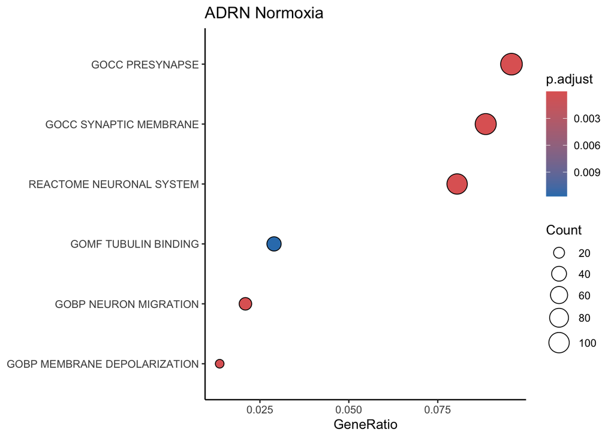

```r
p_adrn_norm <- dotplot(enrichr_RNA_Normoxia_ADRN_vs_MES_Up,
                      font.size = 6,
                       showCategory=c(
                         # The 03 terms below were maintained from Analysis done before
                         # Abstract Submission on 05/20/2022.
                         # These terms ended up not changing considering the
                         # Abstract Submission requests.
                         # Request changes included LFC and top 10% Up and
                         # Down-regulated Genes in the Diff. Gene Exp. Analysis.
                         "GOCC_PRESYNAPSE",
                         "GOCC_SYNAPTIC_MEMBRANE",
                         "REACTOME_NEURONAL_SYSTEM",
                         #"GOCC_MICROTUBULE", This particular term did not hold,
                         # but th idea should have
                         "GOMF_TUBULIN_BINDING", # This term held,
                         # supporting the notion in the line above
                         "GOBP_NEURON_MIGRATION",# If this involves Microtubule,
                         # this term supports the notion above
                         #"GOBP_REGULATION_OF_MICROTUBULE_POLYMERIZATION",
                         #"GOBP_REGULATION_OF_MICROTUBULE_BASED_PROCESS",
                         "GOBP_MEMBRANE_DEPOLARIZATION",
                         "HALLMARK_HYPOXIA",
                         "HALLMARK_TGF_BETA_SIGNALING"
                                      )) + ggtitle("ADRN Normoxia")+
  theme(axis.text.y = element_text(size = 6),
        legend.text=element_text(size=6),
        legend.key.size = unit(0.2, 'cm'))+
  theme_classic()

# Print Graph ADRN Normoxia
p_adrn_norm
```

#### 6.2. MES Normoxia

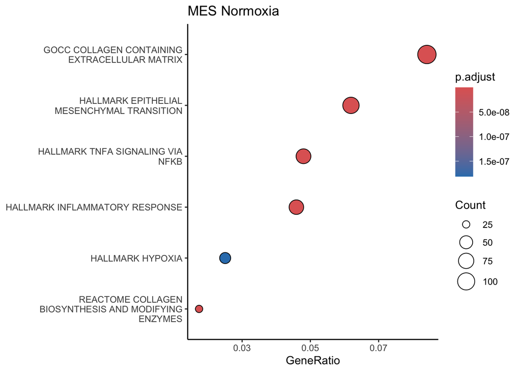

```r
p_mes_norm <- dotplot(enrichr_RNA_Normoxia_ADRN_vs_MES_Down,
                      font.size = 6,
                      showCategory=c(
                        "GOCC_COLLAGEN_CONTAINING_EXTRACELLULAR_MATRIX",
                       "HALLMARK_EPITHELIAL_MESENCHYMAL_TRANSITION",
                       "HALLMARK_TNFA_SIGNALING_VIA_NFKB",
                       "HALLMARK_INFLAMMATORY_RESPONSE",
                       #"HALLMARK_INTERFERON_ALPHA_RESPONSE",
                       #"HALLMARK_INTERFERON_GAMMA_RESPONSE",
                       "HALLMARK_TGF_BETA_SIGNALING",
                       #"HALLMARK_IL2_STAT5_SIGNALING",
                       "HALLMARK_HYPOXIA",
                       #"HALLMARK_GLYCOLYSIS",
                       #"REACTOME_COLLAGEN_FORMATION",
                       #"GOMF_COLLAGEN_BINDING",
                       #"REACTOME_COLLAGEN_CHAIN_TRIMERIZATION",
                       "REACTOME_COLLAGEN_BIOSYNTHESIS_AND_MODIFYING_ENZYMES"
                       #"GOMF_COLLAGEN_BINDING"
                       #"GOBP_COLLAGEN_METABOLIC_PROCESS",
                       #"REACTOME_EXTRACELLULAR_MATRIX_ORGANIZATION",
                       #"GOMF_EXTRACELLULAR_MATRIX_STRUCTURAL_CONSTITUENT",
                       #"REACTOME_DEGRADATION_OF_THE_EXTRACELLULAR_MATRIX"
                       #"GOMF_EXTRACELLULAR_MATRIX_BINDING"
                       )
                      ) + ggtitle("MES Normoxia")+
  theme(axis.text.y = element_text(size = 6),
        legend.text=element_text(size=6),
        legend.key.size = unit(0.2, 'cm'))+
  theme_classic()

# Print Graph MES Normoxia
p_mes_norm
```